# Visualization in R

A SC3L Workshop

Tyler Wiederich

University of Nebraska-Lincoln

## About us

- We are the Statistical Cross-disciplinary Collaboration & Consulting Lab (SC3L) from the UNL Department of Statistics.
- We offer free statistical consulting services to students, faculty, and staff within INAR at UNL.
- Workshops! Hosted from 2-3pm on Wednesdays and 10-11 on Thursdays.

[figure not shown]

# Data Visualization in R

## Why visualize data?

Data visualization is an important step in understanding the relationships of variables in your dataset.

- How does Factor A affect my response?
- Is there an interaction between Factor A and Factor B?
- Are there outliers in my dataset?

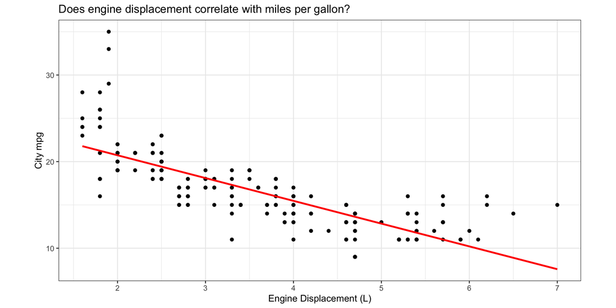

## The basics

R has multiple methods of creating visualizations, but our focus will be with the `ggplot2` package. This package uses the Grammar of Graphics approach, layering different building blocks to produce a graph.

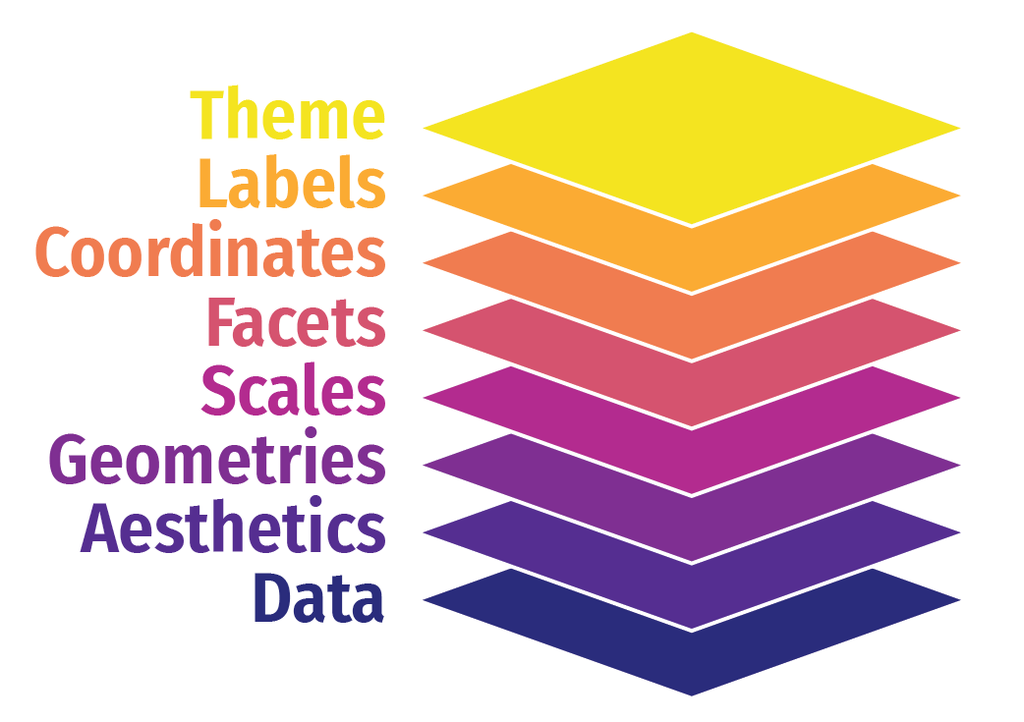

## The basics: data format

Data needs to be formatted so that it is **tidy**, which is defined as one observation per row and each measurement as a column.

| Trt1 | Trt2 | Rep | response |
| --- | --- | --- | --- |
| 1 | 1 | 1 | 9.37 |
| 2 | 1 | 1 | 9.04 |
| 1 | 2 | 1 | 10.84 |
| 2 | 2 | 1 | 10.94 |
| 1 | 1 | 2 | 10.00 |
| 2 | 1 | 2 | 9.63 |
| 1 | 2 | 2 | 9.62 |
| 2 | 2 | 2 | 10.00 |

## Example: not tidy

Average diamond price by cut and color

| color | Fair | Good | Very Good | Premium | Ideal |
| --- | --- | --- | --- | --- | --- |
| E | 11156 | 4535 | 1703 | 4739 | 1799 |
| G | 5924 | NA | 2684 | 5720 | 3266 |
| H | 3862 | NA | 4527 | 5438 | 3448 |
| D | NA | 2406 | 3424 | 1809 | 5855 |
| F | NA | 4549 | 8948 | 2880 | 1780 |
| I | NA | 1952 | 4532 | 4480 | 3734 |
| J | NA | NA | NA | 6348 | 1720 |

## Example: tidy

Average diamond price by cut and color.

| cut | color | price |
| --- | --- | --- |
| Fair | E | 11156 |
| Fair | G | 5924 |
| Fair | H | 3862 |
| Good | D | 2406 |
| Good | E | 4535 |
| Good | F | 4549 |

## The basics: syntax

```r
ggplot(data = data, mapping = aes(...)) +
  geom_FUNCTION(aes(...), ...) +
  scale_FUNCTION(...) +
  facet_FUNCTION(...) +
  labs(title = '', subtitle = '', x = '', y = '') +
  theme_FUNCTION(...) +
  coord_FUNCTION(...)
```

## Preliminaries

```r
install.packages(c('ggplot2', 'palmerpenguins', 'ggthemes'))
library(ggplot2)
library(palmerpenguins)
library(ggthemes)
```

# Example 1

## Example 1: penguins

Palmer Penguins Data

| species | island | bill_length_mm | bill_depth_mm | flipper_length_mm | body_mass_g | sex | year |
| --- | --- | --- | --- | --- | --- | --- | --- |
| Adelie | Torgersen | 39.1 | 18.7 | 181 | 3750 | male | 2007 |
| Adelie | Torgersen | 39.5 | 17.4 | 186 | 3800 | female | 2007 |
| Adelie | Torgersen | 40.3 | 18.0 | 195 | 3250 | female | 2007 |
| Adelie | Torgersen | NA | NA | NA | NA | NA | 2007 |
| Adelie | Torgersen | 36.7 | 19.3 | 193 | 3450 | female | 2007 |
| Adelie | Torgersen | 39.3 | 20.6 | 190 | 3650 | male | 2007 |

## Example 1: penguins

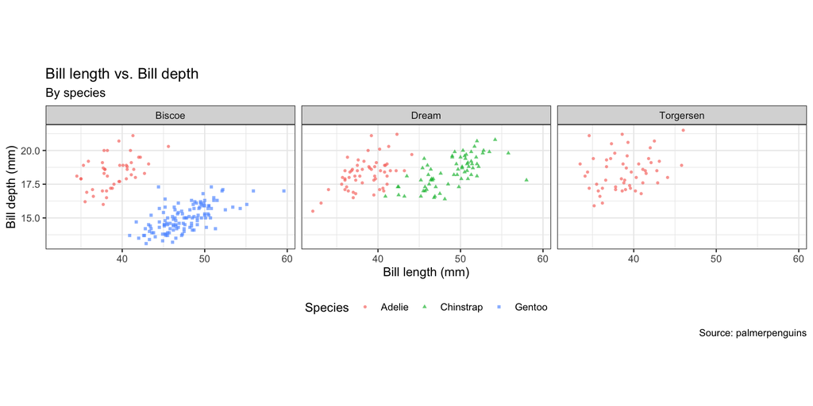

```r
ggplot(data = penguins, mapping = aes(x = bill_length_mm, y = bill_depth_mm, color = species)) +
  geom_point(aes(shape = species), alpha = 2/3, size = 1) +
  theme_bw() +
  labs(x = 'Bill length (mm)', y = 'Bill depth (mm)',
       title = 'Bill length vs. Bill depth', subtitle = 'By species',
       color = 'Species', shape = 'Species', caption = 'Source: palmerpenguins') +
  facet_grid(.~island) +
  theme(aspect.ratio = 1/2,
        legend.position = 'bottom')
```

# Example 2

## Example 2

Does mass differ between penguins species?

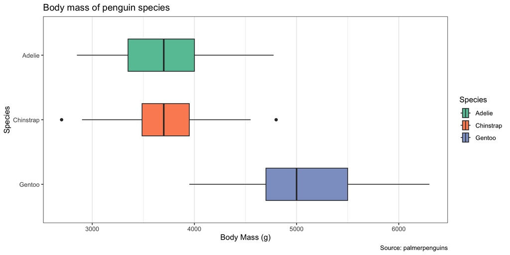

# Example 3

## Example 3

Using the ggplot2::economics dataset, plot the median duration of unemployment over time.

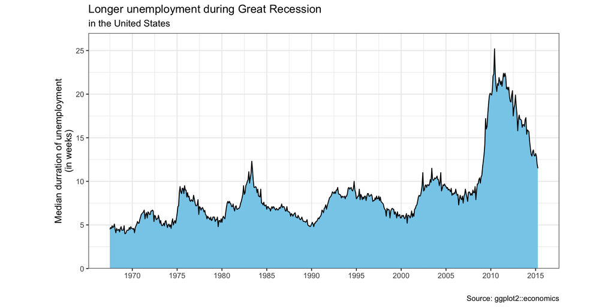

```r
ggplot(data = economics, mapping = aes(x = date, y = uempmed)) +
  # geom_line(color = 'black') +
  geom_area(fill = 'skyblue', color = 'black') +
  theme_bw() +
  labs(x = '',
       y = 'Median durration of unemployment\n(in weeks)',
       title = 'Longer unemployment during Great Recession',
       subtitle = 'in the United States',
       caption = 'Source: ggplot2::economics') +
  scale_x_date(date_breaks = '5 years', date_labels = '%Y') +
  scale_y_continuous(limits = c(0,27), expand = c(0,0)) +
  theme(aspect.ratio = 1/2)
```

# Saving your visualization

## Saving your visualization

```r
myplot <- economics2000s %>%
  ggplot(mapping = aes(x = year, y = mean_unemploy)) +
  geom_bar(stat = 'identity', width = 1,
           color = 'black', fill = 'skyblue') +
  labs(x = '', y = 'Unemployment rate (%)', title = 'Unemployment rate in the United States') +
  scale_y_continuous(limits = c(0, 5), expand = c(0,0)) +
  scale_x_continuous(breaks = 2000:2015) +
  theme_bw() + theme(aspect.ratio = 1/2)

ggsave('unemploy.png', width = 6, dpi = 600)
```

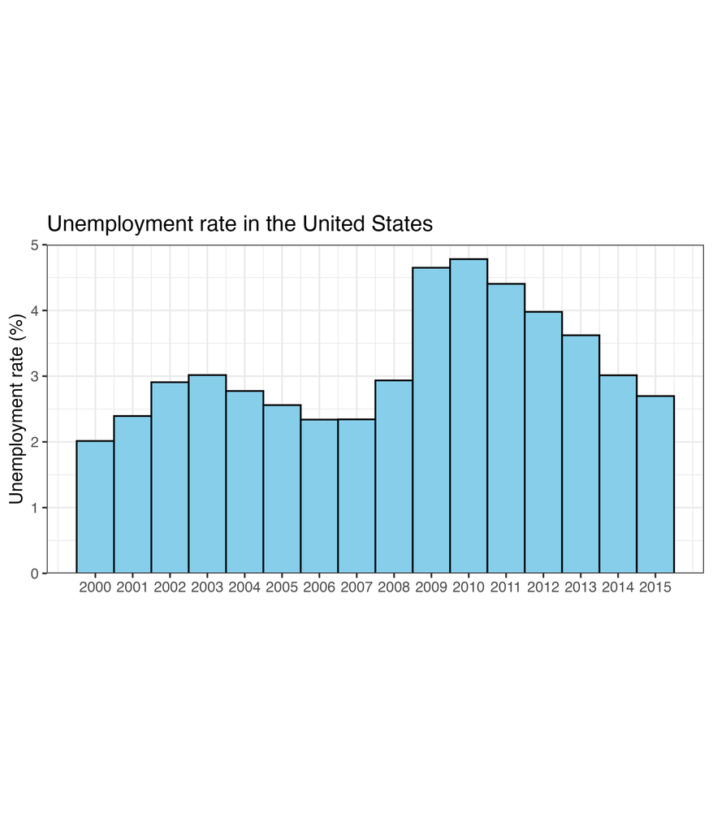

# Wrap-up

## Thank you

Additional resources

- https://ggplot2.tidyverse.org
- https://r-graph-gallery.com/ggplot2-package.html

Visit our website to schedule an appointment! https://statistics.unl.edu/sc3lhelp-desk/

[figure not shown]